# ANGSD_HW_Week_10

Paul Gaudin

3/25/2019

#### Exercise 1

##### What do the columns represent? What do the rows represent?

The column names are the barcodes for each cell, the row names are Gene names, Column x Gene is the gene count for each of the cells with a specified barcode.

##### Create a SingleCellExperiment object.

```r
folder <- "./"

readcounts <- read.table(paste0(folder, "WT-1.dge.txt"),header=TRUE, row.names=1)

counts_matrix <- as.matrix(readcounts)

readcounts$GENE <- NULL

library(SingleCellExperiment)

sce <- SingleCellExperiment(assays = list(counts = counts_matrix, logcounts = log10(counts_matrix)))
sce
```

```
## class: SingleCellExperiment
## dim: 25319 1400
## metadata(0):
## assays(2): counts logcounts
## rownames(25319): A1BG A1BG-AS1 ... ZZZ3 hsa-mir-1273e
## rowData names(0):
## colnames(1400): GGTCCAGATCAT CCCCCATTATGC ... TCCCTTTATCAT
##   CGCCTTCTAATC
## colData names(0):
## reducedDimNames(0):
## spikeNames(0):
```

##### Show a snippet of the count matrix that is now part of the SCE object.

```r
counts(sce)[1:10,1:5]
```

```
##           GGTCCAGATCAT CCCCCATTATGC TTTACCTAACAG ATTCCCGAGTCA ATTCATTCTTTG
## A1BG                 0            0            0            0            0
## A1BG-AS1             0            0            0            0            0
## A2ML1                0            0            0            0            0
## A2ML1-AS1            0            0            0            0            0
## A2ML1-AS2            0            0            0            0            0
## A4GALT               0            0            0            0            0
## AAAS                 1            0            0            0            1
## AACS                 2            0            0            1            1
## AACSP1               0            0            0            0            0
## AADACL3              0            0            0            0            0
```

##### Calculate the numbers of reads (~ sequencing depths) for the first five cells, i.e. you should have 5 values in the end.

```r
for (i in 1:5){
  print(colnames(counts(sce))[i]) ##barcode
  print(sum(counts(sce)[,i])) ##sequencing depth
}
```

```
## [1] "GGTCCAGATCAT"
## [1] 42572
## [1] "CCCCCATTATGC"
## [1] 33667
## [1] "TTTACCTAACAG"
## [1] 30704
## [1] "ATTCCCGAGTCA"
## [1] 28555
## [1] "ATTCATTCTTTG"
## [1] 25858
```

##### How many genes have non-zero counts in the first five cells?

```r
genes_with_non_zero_counts <- 0
counts_matrix = counts(sce)
for (i in 1:nrow(counts_matrix)){
  if(sum(counts_matrix[i,1:5]) > 0){
    genes_with_non_zero_counts <- genes_with_non_zero_counts + 1
  }
}

genes_with_non_zero_counts
```

```
## [1] 12066
```

##### If you were to change the row- and column-names of the original matrix, how could you keep track of the original names?

You could create an object that has keys that are the new row or column names, and values that are the original row and column names.

##### Following the simpleSingleCell workflow, generate histograms or density plots of (a) the total number of UMI counts per cell and (b) total number of expressed genes. (1pt plus 1pt extra-credit if you generate the plots with ggplot2).

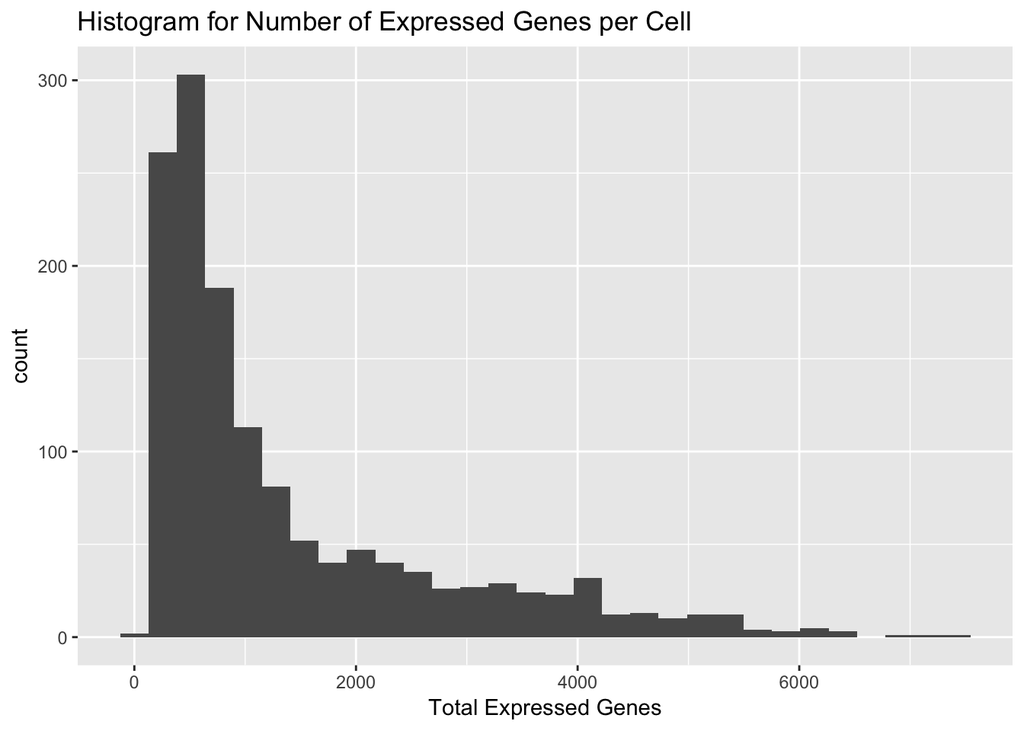

```r
total_expressed_genes = c()
total_umi_count = c();
for (i in 1:ncol(counts_matrix)){
  total_expressed_genes = c(total_expressed_genes,sum(counts_matrix[,i] > 0))
}


#hist(log10(total_expressed_genes), breaks=30, col="grey80",xlab="Log10-total expressed genes")

#hist(log10(total_umi_count), breaks=30, col="grey80",xlab="Log10-total UMI count")

library(ggplot2)

df_eg = data.frame(colnames(sce),total_expressed_genes)

ggplot(df_eg, aes(x=total_expressed_genes)) + geom_histogram() + geom_histogram(bins = 30) + xlab("Total Expressed Genes") + ggtitle("Histogram for Number of Expressed Genes per Cell")
```

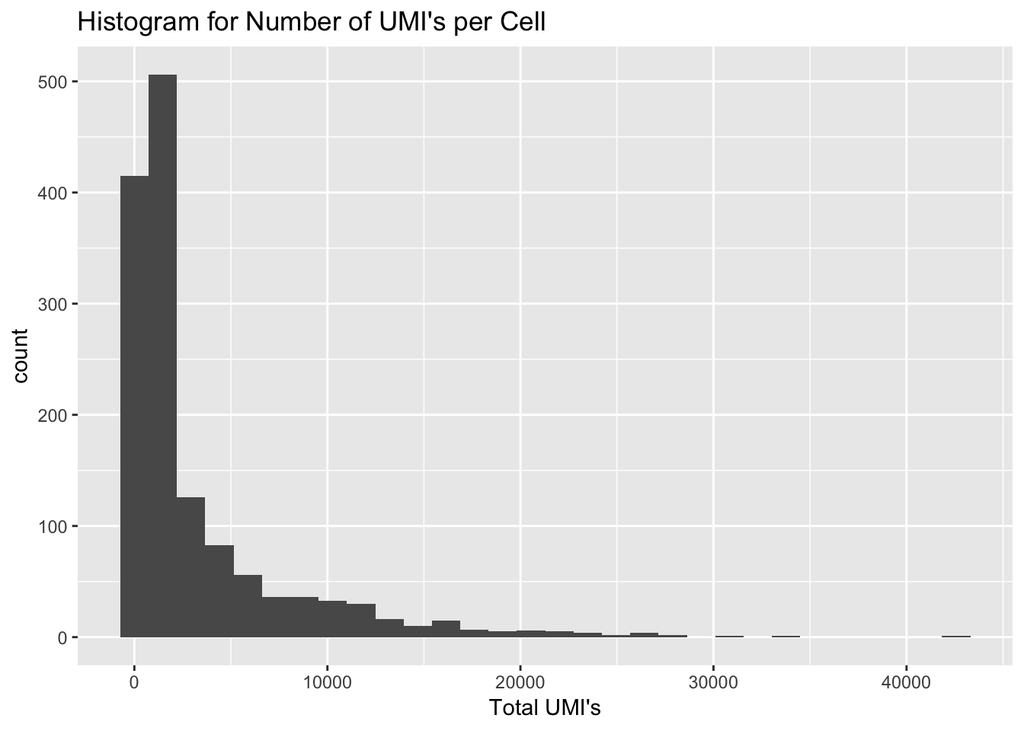

```r
total_UMI_count = c();
for (i in 1:ncol(counts_matrix)){
  total_umi_count = c(total_umi_count,sum(counts_matrix[,i]))
}

df_umi = data.frame(colnames(sce), total_umi_count)
ggplot(df_umi, aes(x=total_umi_count)) + geom_histogram() + geom_histogram(bins = 30) + xlab("Total UMI's") + ggtitle("Histogram for Number of UMI's per Cell")
```

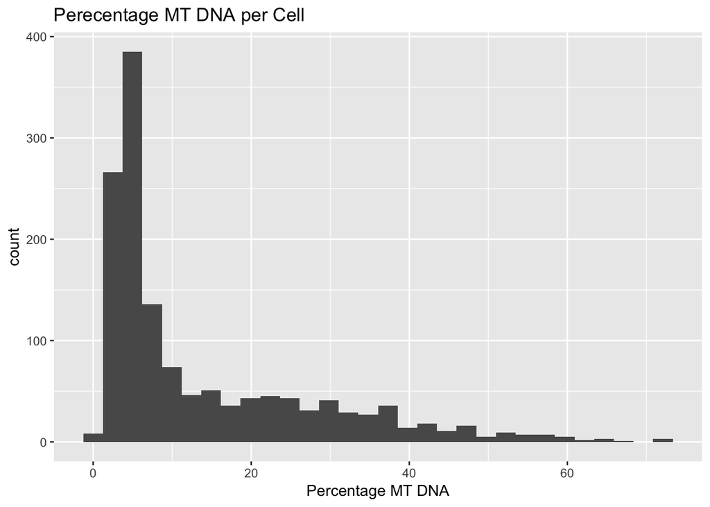

```r
mt_genes <- c();

for (i in 1:nrow(counts_matrix)){
  if (grepl("MT-", rownames(counts_matrix)[i])){
    mt_genes <- c(mt_genes, rownames(counts_matrix)[i])
  }
}

mt_count_matrix = subset(counts_matrix, rownames(counts_matrix) %in% mt_genes)


total_mt_count = c();

for (i in 1:ncol(mt_count_matrix)){
  total_mt_count = c(total_mt_count,sum(mt_count_matrix[,i]))
}

mt_percentage <- 100*round(total_mt_count / total_umi_count,3)

df_mt_percentage = data.frame(colnames(sce), mt_percentage)
ggplot(df_mt_percentage, aes(x=mt_percentage)) + geom_histogram() + geom_histogram(bins = 30) + xlab("Percentage MT DNA") + ggtitle("Perecentage MT DNA per Cell")
```

##### Decide on some threshold for either QC parameter and remove the corresponding cells.

Remove cells with MT-DNA percentage over 30%

Bottom and top 5% UMI - remove empty droplets as well as doublets.

```r
umi_sorted <- sort(total_umi_count)

umi_bottom_cutoff_index <- length(total_umi_count) * 0.05

umi_top_cutoff_index <- length(total_umi_count) * 0.95

umi_bottom_cutoff <- umi_sorted[umi_bottom_cutoff_index]

umi_top_cutoff <- umi_sorted[umi_top_cutoff_index]

normalized_counts_matrix <- counts_matrix

mt_remove_vector <- c();

for (i in 1:length(mt_percentage)){
  if (!is.na(mt_percentage[i])){
    if (mt_percentage[i] > 30){
      mt_remove_vector <- c(mt_remove_vector, i)
    }
  }
}

normalized_counts_matrix <- normalized_counts_matrix[,-mt_remove_vector]


i = 1
while (i < ncol(normalized_counts_matrix)){
  if(sum(normalized_counts_matrix[,i]) < umi_bottom_cutoff | sum(normalized_counts_matrix[,i]) > umi_top_cutoff){
    normalized_counts_matrix <- normalized_counts_matrix[,-i]
  }
  i <- i + 1
}
```

##### Using the filtered data set, normalize the counts using scran and scater and judge whether the size factors calculated by computeSumFactors show the expected behavior as shown in Figure 6 of the simpleSingleCell workflow.

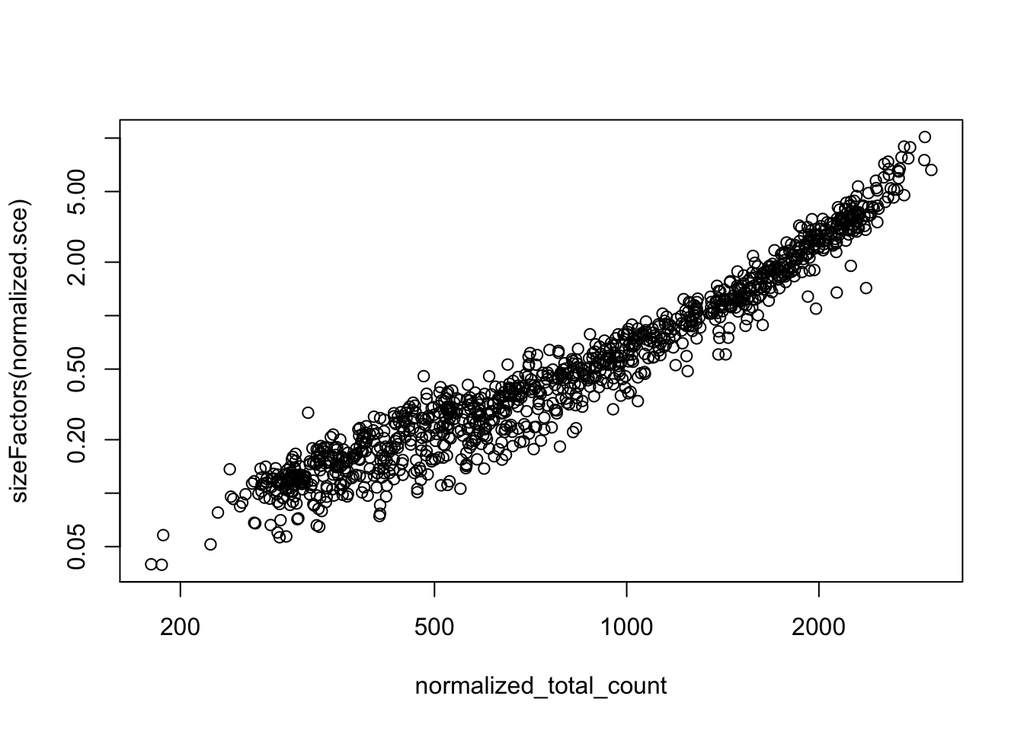

```r
library(scran)
library(scater)

normalized.sce <- SingleCellExperiment(assays = list(counts = normalized_counts_matrix, logcounts = log10(normalized_counts_matrix)))

normalized.sce <- scran::computeSumFactors(normalized.sce)
normalized.sce <- normalize(normalized.sce)

normalized_total_count = c();

for (i in 1:ncol(normalized_counts_matrix)){
  normalized_total_count = c(normalized_total_count,sum(count(normalized_counts_matrix[,i])))
}

plot(normalized_total_count, sizeFactors(normalized.sce), log="xy")
```

###### How can you access the normalized data matrix?

As seen above, you can access the normalized data matrix via normalized.sce, for example:

```r
summary(sizeFactors(normalized.sce))
```

```
##    Min. 1st Qu.  Median    Mean 3rd Qu.    Max.
##  0.0395  0.1829  0.4073  1.0000  1.2347 10.1445
```

```r
counts(normalized.sce)[1:10,1:5]
```

```
##           CCCCCATTATGC ATTCCCGAGTCA GTCTTCTCCCAT TTCCAGCCTCGG TTCGCTGAAAAC
## A1BG                 0            0            0            0            0
## A1BG-AS1             0            0            0            0            0
## A2ML1                0            0            1            0            0
## A2ML1-AS1            0            0            0            0            0
## A2ML1-AS2            0            0            0            0            0
## A4GALT               0            0            0            0            0
## AAAS                 0            0            0            0            0
## AACS                 0            1            2            0            0
## AACSP1               0            0            0            0            0
## AADACL3              0            0            0            0            0
```

#### Exercise 2. scRNA-seq data wrangling in R using Seurat.

##### Create a Seurat object (function: Seurat::CreateSeuratObject)

```r
library(Seurat)
seurat <- CreateSeuratObject(raw.data = readcounts)
```

##### Perform the same filtering that you chose to do on the SCE object. (1pt)

```r
seurat.filtered <- FilterCells(object = seurat, subset.names = c("nGene"), low.thresholds = c(umi_bottom_cutoff), high.thresholds = c(umi_top_cutoff))
```

##### Normalize the data using Seurat’s function for this (NormalizeData). (.5pt)

```r
seurat.filtered.normalized <- NormalizeData(object = seurat.filtered, normalization.method = "LogNormalize", scale.factor = 10000)
```

###### How can you access the normalized data matrix? (Answer 7 of Seurat’s FAQ should be helpful here) (0.5pts)

You can access the normalized data matrix via seurat.filtered.normalized@data, for example:

```r
seurat.filtered.normalized@data[1:5,1:10]
```

```
## 5 x 10 sparse Matrix of class "dgCMatrix"
```

```
##    [[ suppressing 10 column names 'GGTCCAGATCAT', 'CCCCCATTATGC', 'TTTACCTAACAG' ... ]]
```

```
##
## A1BG      . . . . . .         . . . .
## A1BG-AS1  . . . . . .         . . . .
## A2ML1     . . . . . 0.3636412 . . . .
## A2ML1-AS1 . . . . . .         . . . .
## A2ML1-AS2 . . . . . .         . . . .
```

##### For the first 10 cells, do pairwise comparisons for each cell of the normalized values from the Seurat object and the SCE object (scatter plots are fine; you may want to check out the GGally package, specifically the ggpairs function. We also recommend to remove genes that have zero counts in all the samples). Explain what you see. (2pts)

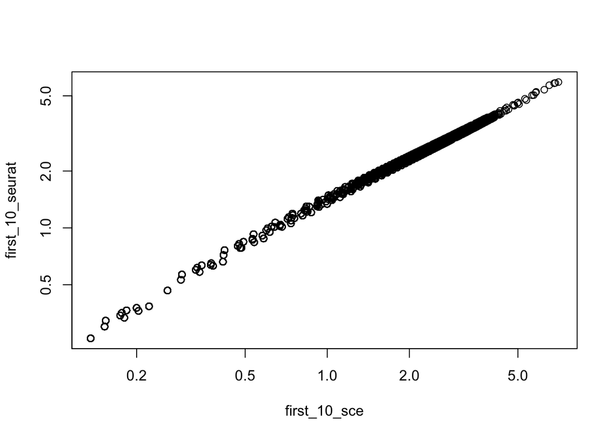

```r
first_10_sce = c()
first_10_seurat = c()
norm_sce_log_counts = logcounts(normalized.sce)

cells = c("CCCCCATTATGC","ATTCCCGAGTCA","GTCTTCTCCCAT","TTCCAGCCTCGG","TTCGCTGAAAAC","ACTAAGTAAGCT","GTTTTCTACAGC","CCGTCTGGTGAC","CACTTTCTTGTC","ATAATGACGGCT") ## make sure to compare identical cells


for (i in cells){
  for (j in 1:nrow(normalized_counts_matrix)){
    if(normalized_counts_matrix[j,i] > 0 && seurat.filtered.normalized@data[j,i] > 0){
      first_10_sce = c(first_10_sce,norm_sce_log_counts[j,i])
      first_10_seurat = c(first_10_seurat, seurat.filtered.normalized@data[j,i])
    }
  }
}

plot(first_10_sce,first_10_seurat, log="xy")
```

#### Exercise 3. What types of cells do you think you’re looking at?

To determine what cells we are examing, one can look at the most highly expressed genes (and thereby proteins for protein coding genes) to determine which cell population is present. Below, I will look at the Top 40 most highly expressed genes among the mainly homogenous population.

```r
genes_counts <- c()
for (i in 1:nrow(counts_matrix)){
  genes_counts <- c(genes_counts, sum(counts_matrix[i,]))
}

genes_counts_sorted <- sort(genes_counts, decreasing = TRUE)

top_40_cutoff <- genes_counts_sorted[41]

genes = rownames(counts_matrix)
top_40_genes = c();

for (i in 1:nrow(counts_matrix)){
  if(sum(counts_matrix[i,]) > top_40_cutoff){
    top_40_genes = c(top_40_genes, genes[i]);
  }
}

top_40_genes
```

```
##  [1] "ACTG1"        "CER1"         "HNRNPA2B1"    "HSP90AA1"
##  [5] "HSP90AB1"     "HSP90B1"      "MT-ATP6"      "MT-CO1"
##  [9] "MT-CO2"       "MT-CO3"       "MT-CYB"       "MT-ND4"
## [13] "MT-RNR2"      "NCL"          "PABPC1"       "PTMA"
## [17] "RP11-148B6.1" "RPL11"        "RPL13"        "RPL19"
## [21] "RPL23"        "RPL27A"       "RPL30"        "RPL31"
## [25] "RPL35A"       "RPL37A"       "RPLP1"        "RPLP2"
## [29] "RPS12"        "RPS14"        "RPS17L"       "RPS19"
## [33] "RPS2"         "RPS27A"       "RPS3"         "RPS5"
## [37] "RPS6"         "RPS8"         "TMSB10"       "VIM"
```

When investigating the Top 40 genes, a number of the genes are indicative of the cell type, including CER1, ACTG1, NCL, VIM, PTMA, and PABC1. According to scRNASeqDB (https://bioinfo.uth.edu/scrnaseqdb/), these genes are all very highly expressed in human embryonic stem cells, which I am predicting the WT-1 cells originated from.